# CIENCIA DE DATOS GEOGRÁFICA - PRACTICA 1

Ángeles Scetta

FLACSO, 2025

## EJERCICIO DE PRÁCTICA

### Ciudad: Montevideo, Uruguay

*Fuente de datos: https://catalogodatos.gub.uy/*

**CONSIGNA: PARTE 1**

1. Abrir en este RMarkdown (.Rmd) el dataset de monumentos y bienes (.csv) y el de municipios (.geoJSON). Ambos se encuentran en la carpeta *data*.

```r
library(tidyverse)
library(sf)
montevideo_municipios <- st_read("data/montevideo_municipios.geojson")
montevideo_bienes <- read_csv("data/monumentos_bienes.csv")
```

2. Explorar el contenido de ambos dataset. Mapear los municipios.

```r
dim(montevideo_bienes)
```

```
## [1] 629   7
```

```r
dim(montevideo_municipios)
```

```
## [1] 8 4
```

```r
head(montevideo_bienes)
```

```
## # A tibble: 6 × 7
##   RESOLUCION         IDENTIFICA DIRECCION PROTECCION OBSERVACIO PADRON MUNICIPIO
##   <chr>              <chr>      <chr>     <chr>      <chr>       <dbl> <chr>
## 1 286/995            Cabaña «S… Camino d… MONUMENTO… <NA>       123643 G
## 2 Ley 16736 del 02/… Hipódromo… Entre Co… MONUMENTO… <NA>        43977 G
## 3 293/986            Cabaña «S… Con. Fél… MONUMENTO… <NA>       123726 G
## 4 293/986            Cabaña «S… Camino d… MONUMENTO… <NA>       123727 G
## 5 Dº 31.598          Casa que … Ruta 5 y… BIEN DE I… <NA>        43598 G
## 6 Dº 31.598          Casa que … Ruta 5 y… BIEN DE I… <NA>        43598 G
```

```r
head(montevideo_municipios)
```

```
## Simple feature collection with 6 features and 3 fields
## Geometry type: MULTIPOLYGON
## Dimension:     XY
## Bounding box:  xmin: -56.35262 ymin: -34.93815 xmax: -56.02395 ymax: -34.70192
## Geodetic CRS:  WGS 84
##   GID MUNICIPIO  AREA_HA                       geometry
## 1  33         G 14240.00 MULTIPOLYGON (((-56.31356 -...
## 2  34         D  8603.33 MULTIPOLYGON (((-56.14134 -...
## 3  35         F  8514.36 MULTIPOLYGON (((-56.06003 -...
## 4  36         E  2683.40 MULTIPOLYGON (((-56.05698 -...
## 5  37        CH  1194.85 MULTIPOLYGON (((-56.15064 -...
## 6  38         B  1147.59 MULTIPOLYGON (((-56.16518 -...
```

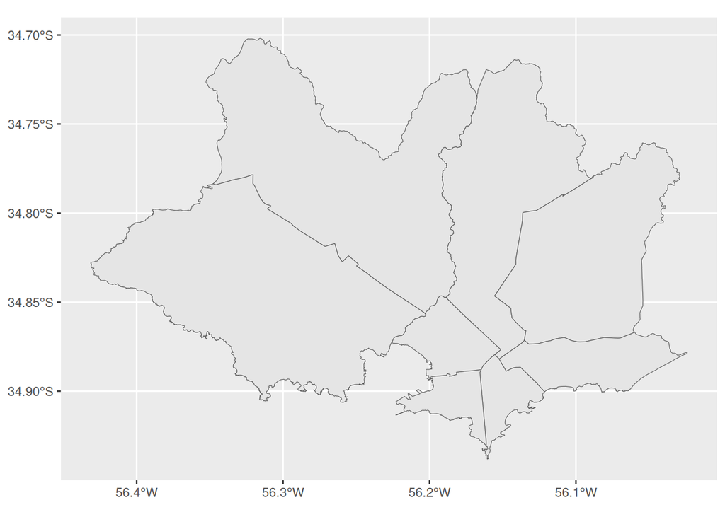

```r
ggplot()+
  geom_sf(data = montevideo_municipios)
```

3. Realizar una unión entre ambos dataset, asignando a cada Municipio la cantidad de Monumentos Históricos y Bienes de Interés Municipal que contiene.

3a. Unir monumentos y bienes por municipio

```r
montevideo_bienes <- montevideo_bienes %>%
  group_by(MUNICIPIO) %>%
  summarise(cantidad= n())
```

```r
head(montevideo_bienes)
```

```
## # A tibble: 6 × 2
##   MUNICIPIO cantidad
##   <chr>        <int>
## 1 A                8
## 2 B              187
## 3 C              241
## 4 CH              57
## 5 D                6
## 6 E               16
```

3b. Unir las tablas

```r
montevideo_combinado <- left_join(montevideo_municipios, montevideo_bienes, by= "MUNICIPIO")
```

4. Utilizar `ggplot()` y `geom_sf()` para realizar un mapa coroplético con los límites de los Municipios y colorear el relleno (*fill*) indicando la cantidad de Monumentos y Bienes encontrada en cada uno. *Si se animan, pueden agregar etiquetas en el mapa con `geom_sf_text()`*

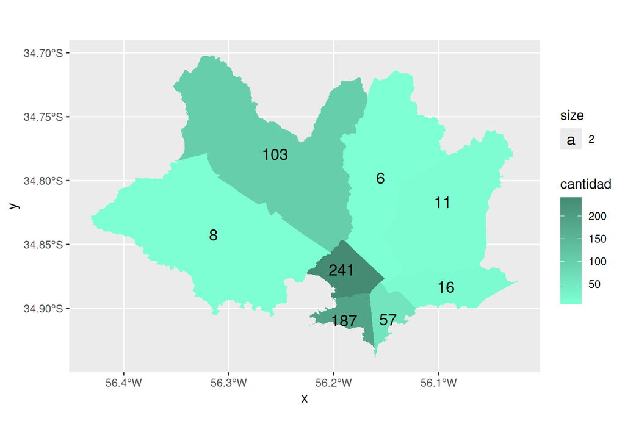

```r
ggplot()+
  geom_sf(data=montevideo_combinado, aes(fill=cantidad), color=NA)+
  geom_sf_text(data = montevideo_combinado, aes( label = cantidad, size = 2))+
  scale_fill_gradient(low = "aquamarine", high = "aquamarine4")
```

```r
  labs(title= "Monumentos y bienes por municipio",
       fill= "Monumentos y bienes/municipios")+
  theme_minimal()
```

**CONSIGNA: PARTE 2**

1. Utilizar `filter()` y `geom_sf()` para hacer un mapa coroplético que tenga coloreados solo los Municipios que cuentan con más de 25 monumentos y bienes históricos. Agregar polígonos de fondo para dar contexto.

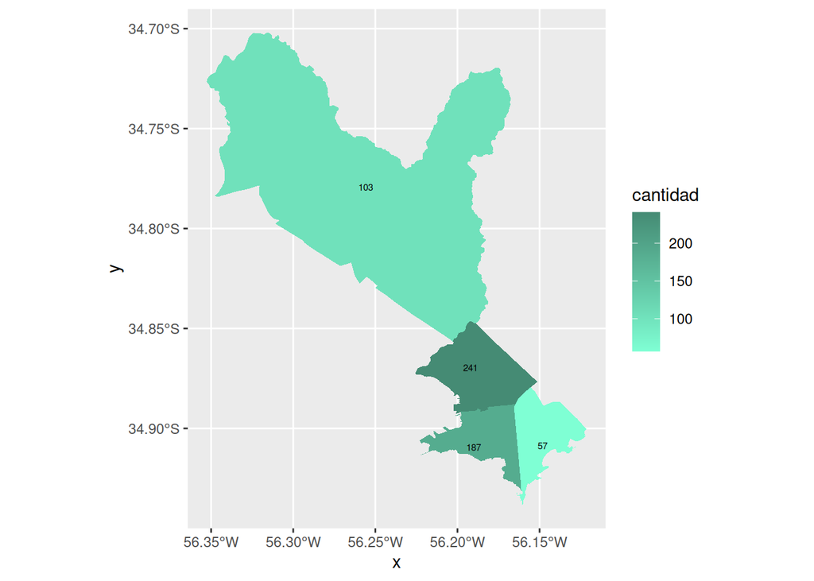

```r
ggplot()+
  geom_sf(data= filter(montevideo_combinado, cantidad>25), aes(fill=cantidad), color=NA)+
  geom_sf_text(data=filter(montevideo_combinado, cantidad>25), aes(label=cantidad), size = 2)+
  scale_fill_gradient(low = "aquamarine", high = "aquamarine4")
```

```r
labs(title= "Monumentos y bienes por municipio",
     fill="Monumentos y bienes/municipios",
     x="",
     y="")+
  theme_minimal()
```

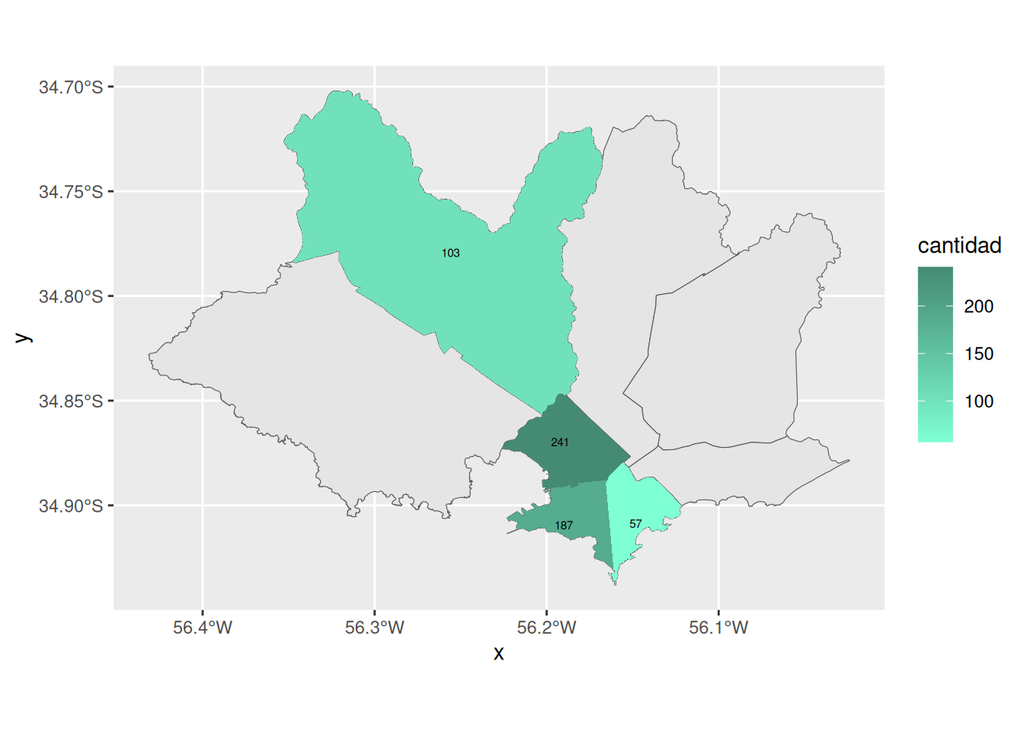

```r
ggplot()+
  geom_sf(data = montevideo_municipios)+
  geom_sf(data= filter(montevideo_combinado, cantidad>25), aes(fill=cantidad), color=NA)+
  geom_sf_text(data=filter(montevideo_combinado, cantidad>25), aes(label=cantidad), size = 2)+
  scale_fill_gradient(low = "aquamarine", high = "aquamarine4")
```

```r
labs(title= "Monumentos y bienes por municipio",
     fill="Monumentos y bienes/municipios",
     x="",
     y="")+
  theme_minimal()
```

Crear la variable categórica para más y menos de 25

```r
montevideo_combinado <- montevideo_combinado %>%
  mutate(categoria=as.factor(if_else(cantidad>25, "Más de 25", "Menos de 25")))
```

Colorear según la categoría

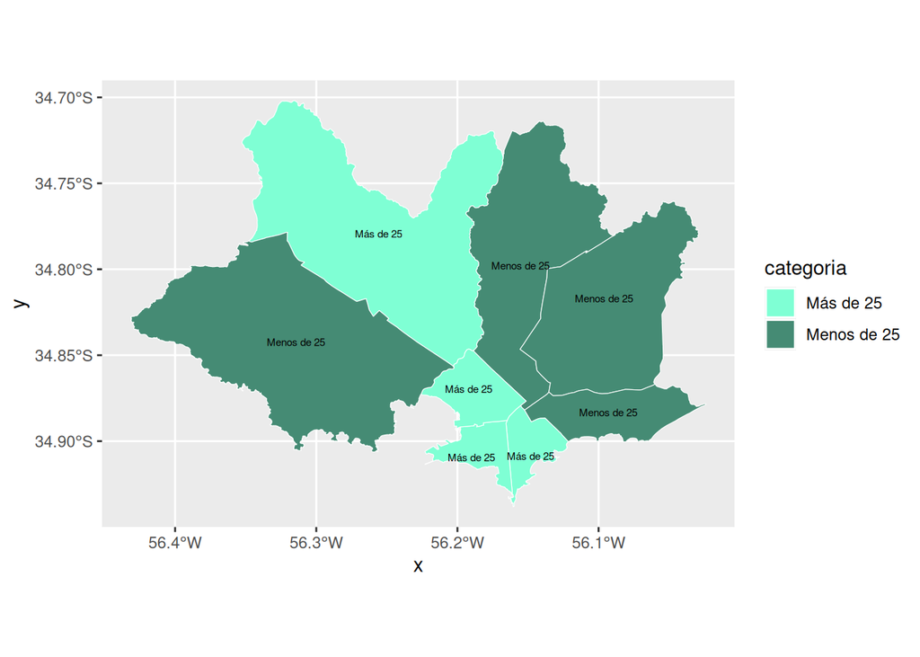

```r
ggplot()+
  geom_sf(data=montevideo_combinado, aes(fill=categoria), color="white")+
  geom_sf_text(data = montevideo_combinado, aes(label=categoria), size=2)+
  scale_fill_manual(values = c("Más de 25"= "aquamarine", "Menos de 25"= "aquamarine4"))
```

```r
labs(title="Monumentos y bienes por municipio",
     subtitle = "Más y menos de 25",
     fill= "Monumentos y bienes/municipios",
     x="",
     y="")+
  theme_minimal()
```